# Data-624 Homework-3

## —————————————————————————

### **Student Name :** Sachid Deshmukh

### **Date :** 02/21/2020

- > [RPubs location of published file](http://rpubs.com/sachid/Data624-Homework3)

## —————————————————————————

## 6.2 The plastics data set consists of the monthly sales (in thousands) of product A for a plastics manufacturer for five years.

### a. Plot the time series of sales of product A. Can you identify seasonal fluctuations and/or a trend-cycle

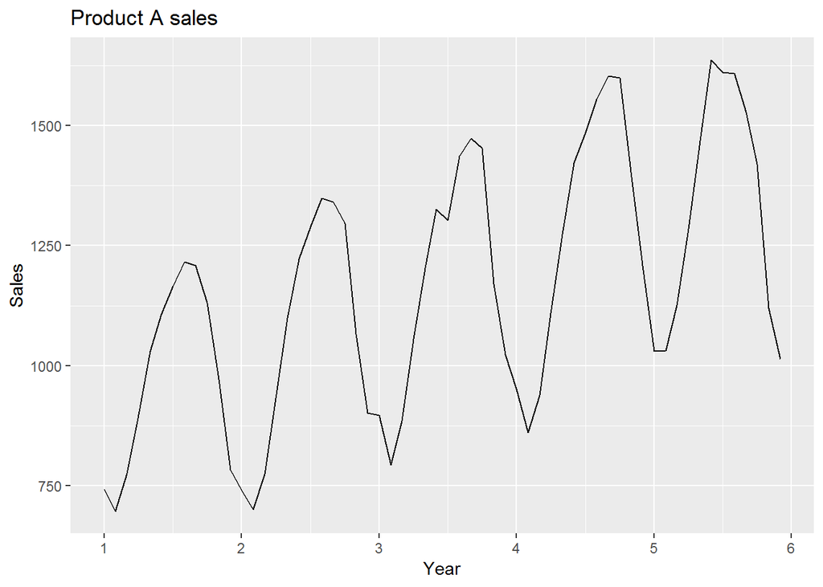

```r
autoplot(plastics) +
  ggtitle("Product A sales") +
  xlab("Year") +
  ylab("Sales")
```

#### Product A sales shows strong seasonal pattern. Sales is down in the beginning and end of the year but spikes in mid year

### b. Use a classical multiplicative decomposition to calculate the trend-cycle and seasonal indices

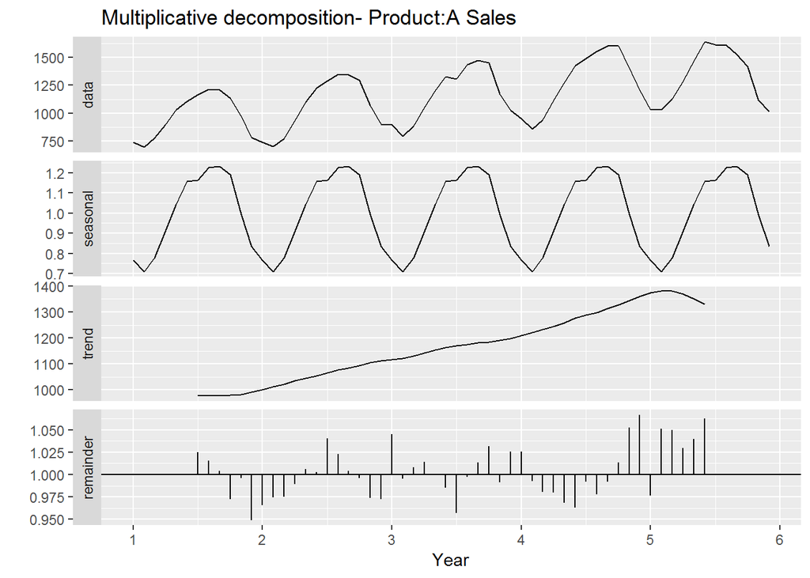

```r
plastics %>% decompose(type = "multiplicative") %>%
  autoplot() + xlab("Year") +
  ggtitle("Multiplicative decomposition- Product:A Sales")
```

### c. Do the results support the graphical interpretation from part a?

#### Classical decomposition results are inline with graphical interpretation from part a

### d. Compute and plot the seasonally adjusted data

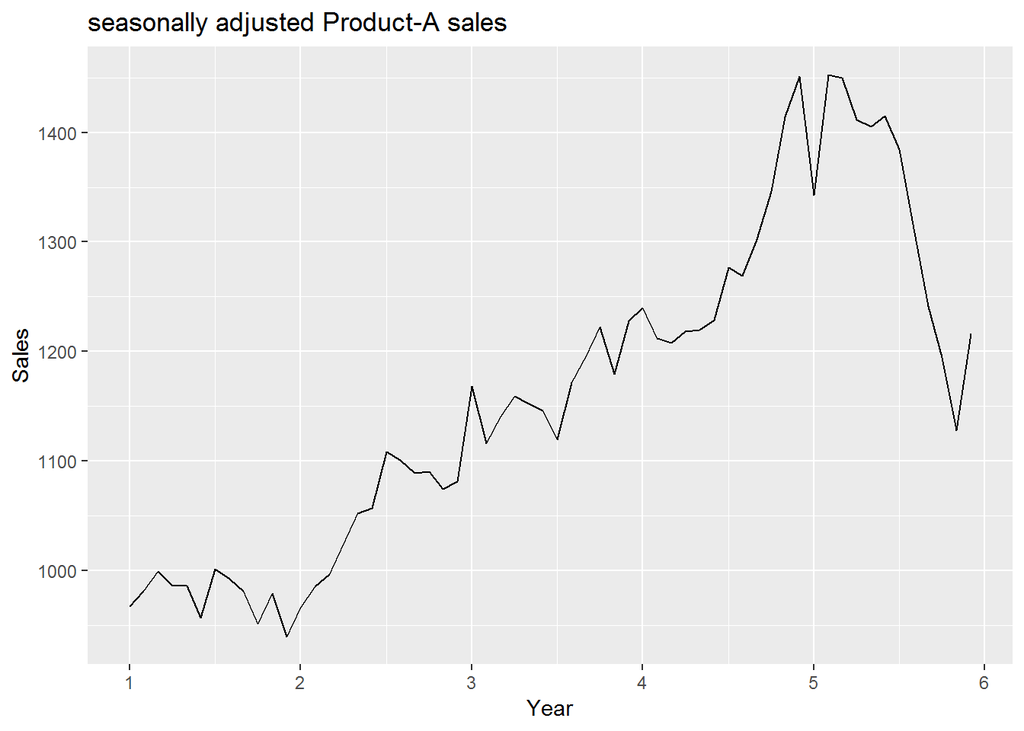

```r
plas.adj <- seasadj(decompose(plastics, type = "multiplicative"))
autoplot(plas.adj) +
  ggtitle("seasonally adjusted Product-A sales") +
  xlab("Year") +
  ylab("Sales")
```

### e. Change one observation to be an outlier (e.g. add 500 to one observation), and recompute the seasonally adjusted data. What is the effect of the outlier?

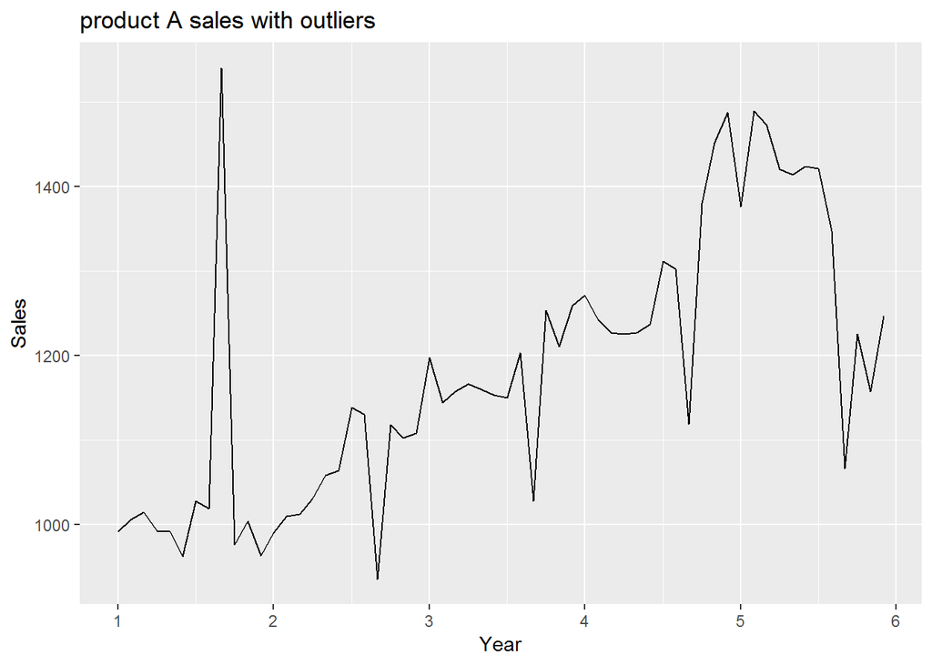

```r
plas9 <- plastics
plas9[9] <- plas9[9] + 1000
plas.adj <- seasadj(decompose(plas9, type = "multiplicative"))
autoplot(plas.adj) +
  ggtitle("product A sales with outliers") +
  xlab("Year") +
  ylab("Sales")
```

#### Outlier causes huge spike at specific time inerval in the time series

### f. Does it make any difference if the outlier is near the end rather than in the middle of the time series?

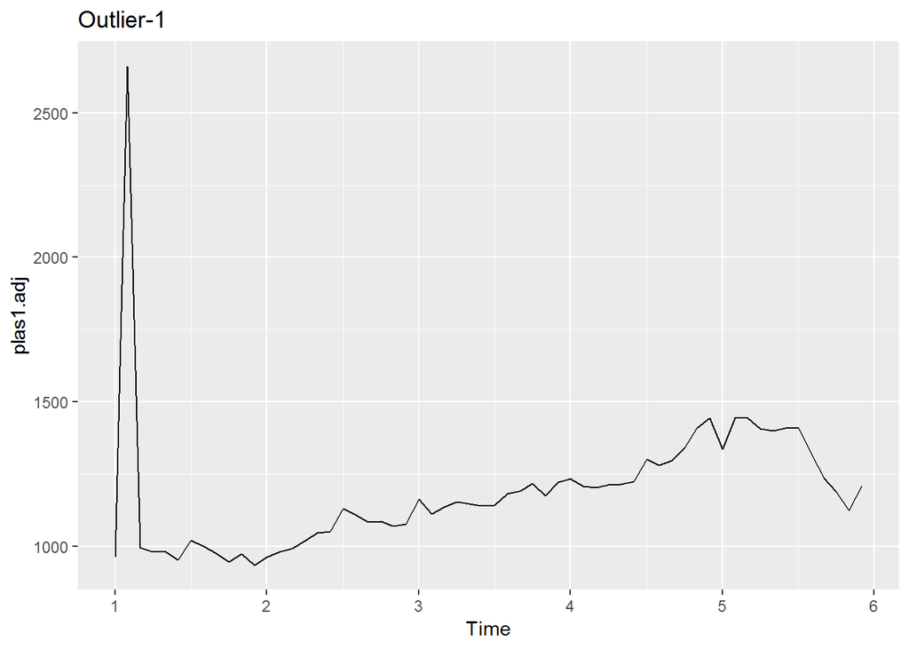

```r
plas1 <- plastics
plas2 <- plastics

plas1[2] <- plas1[2] + 1200
plas2[55] <- plas2[55] + 1200

plas1.adj <- seasadj(decompose(plas1, type = "multiplicative"))
plas2.adj <- seasadj(decompose(plas2, type = "multiplicative"))

autoplot(plas1.adj) +
  ggtitle("Outlier-1")
```

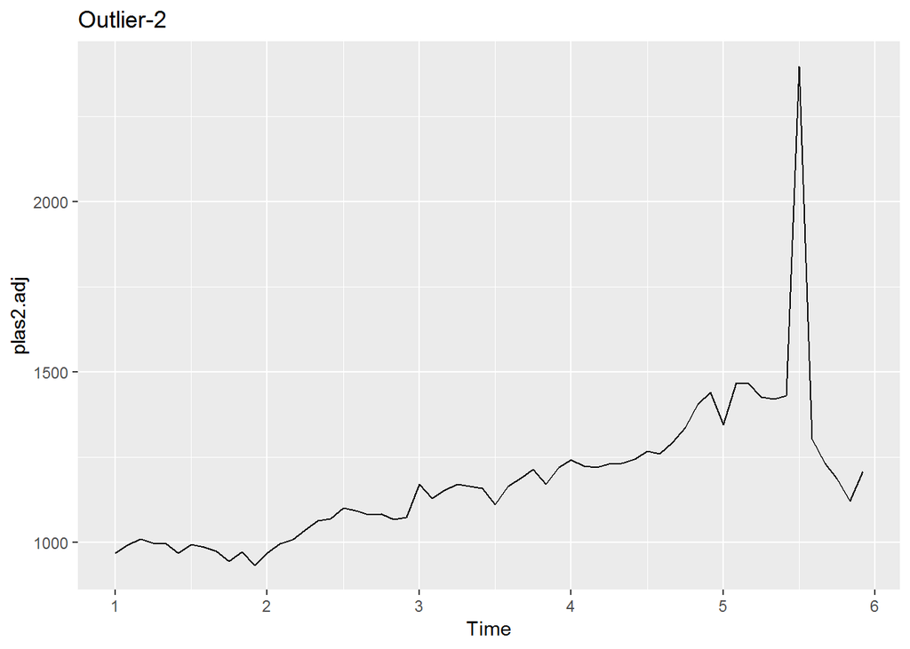

```r
autoplot(plas2.adj) +
  ggtitle("Outlier-2")
```

## 6.3 Recall your retail time series data (from Exercise 3 in Section 2.10). Decompose this series using X11. Does it reveal any outliers or unusual features you had not noticed previously?

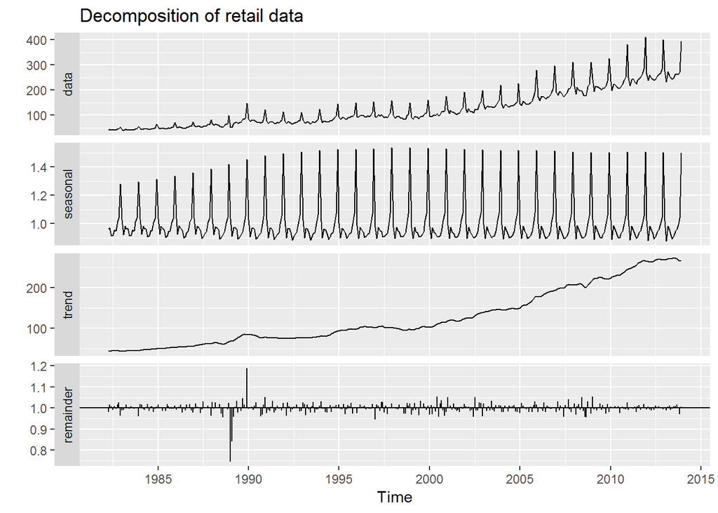

```r
retaildata <- readxl::read_excel("retail.xlsx", skip=1)

myts <- ts(retaildata[,"A3349627V"],
  frequency=12, start=c(1982,4))

fit <- seas(myts)
autoplot(fit) +
  ggtitle("Decomposition of retail data")
```